# Lab 7

Author

Shawheen Ghezavat

[View this project on GitHub](https://github.com/shxwheen/msba-ml-labs/blob/main/lab7/lab7.html)

# Imports

```python
import pandas as pd
import numpy as np
from sklearn.pipeline import Pipeline
from sklearn.compose import make_column_selector, ColumnTransformer
from sklearn.preprocessing import StandardScaler, OneHotEncoder
from sklearn.model_selection import cross_val_score, GridSearchCV, cross_validate
from sklearn.neighbors import KNeighborsClassifier
from sklearn.linear_model import LogisticRegression
from sklearn.tree import DecisionTreeClassifier
from sklearn.metrics import confusion_matrix, roc_auc_score, roc_curve, ConfusionMatrixDisplay
import matplotlib.pyplot as plt
import warnings
from sklearn.exceptions import ConvergenceWarning
warnings.filterwarnings('ignore', category=ConvergenceWarning)
from plotnine import *
```

# Read In CSV

```python
ha = pd.read_csv("https://www.dropbox.com/s/aohbr6yb9ifmc8w/heart_attack.csv?dl=1")
ha.head()
```

|  | age | sex | cp | trtbps | chol | restecg | thalach | output |
| --- | --- | --- | --- | --- | --- | --- | --- | --- |
| 0 | 63 | 1 | 3 | 145 | 233 | 0 | 150 | 1 |
| 1 | 37 | 1 | 2 | 130 | 250 | 1 | 187 | 1 |
| 2 | 56 | 1 | 1 | 120 | 236 | 1 | 178 | 1 |
| 3 | 57 | 0 | 0 | 120 | 354 | 1 | 163 | 1 |
| 4 | 57 | 1 | 0 | 140 | 192 | 1 | 148 | 1 |

# Data Exploration

```python
# Check dataset shape and structure
print(f"Dataset shape: {ha.shape}")
print(f"\nData types:\n{ha.dtypes}")
print(f"\nMissing values:\n{ha.isnull().sum()}")
print(f"\nTarget variable distribution:\n{ha['output'].value_counts()}")
```

```
Dataset shape: (273, 8)

Data types:
age        int64
sex        int64
cp         int64
trtbps     int64
chol       int64
restecg    int64
thalach    int64
output     int64
dtype: object

Missing values:
age        0
sex        0
cp         0
trtbps     0
chol       0
restecg    0
thalach    0
output     0
dtype: int64

Target variable distribution:
output
1    146
0    127
Name: count, dtype: int64
```

```python
# Summary statistics
ha.describe()
```

|  | age | sex | cp | trtbps | chol | restecg | thalach | output |
| --- | --- | --- | --- | --- | --- | --- | --- | --- |
| count | 273.000000 | 273.000000 | 273.000000 | 273.000000 | 273.000000 | 273.000000 | 273.000000 | 273.000000 |
| mean | 54.347985 | 0.673993 | 0.974359 | 132.098901 | 246.860806 | 0.538462 | 149.446886 | 0.534799 |
| std | 9.163134 | 0.469611 | 1.030456 | 17.700358 | 52.569726 | 0.528059 | 23.240707 | 0.499704 |
| min | 29.000000 | 0.000000 | 0.000000 | 94.000000 | 126.000000 | 0.000000 | 71.000000 | 0.000000 |
| 25% | 47.000000 | 0.000000 | 0.000000 | 120.000000 | 211.000000 | 0.000000 | 133.000000 | 0.000000 |
| 50% | 56.000000 | 1.000000 | 1.000000 | 130.000000 | 240.000000 | 1.000000 | 152.000000 | 1.000000 |
| 75% | 61.000000 | 1.000000 | 2.000000 | 140.000000 | 275.000000 | 1.000000 | 166.000000 | 1.000000 |
| max | 77.000000 | 1.000000 | 3.000000 | 200.000000 | 564.000000 | 2.000000 | 202.000000 | 1.000000 |

# Part One: Fitting Models

## Data Preprocessing Setup

```python
# Separate features and target
X = ha.drop('output', axis=1)
y = ha['output']

# Create preprocessing with ColumnTransformer
preprocessor = ColumnTransformer([
    ("standardize", StandardScaler(), ['age', 'trtbps', 'chol', 'thalach']),
    ("dummify", OneHotEncoder(drop='first', sparse_output=False), ['sex', 'cp', 'restecg'])
  ],
  remainder="drop"
)
```

## Q1: K-Nearest Neighbors (KNN)

```python
# Create KNN pipeline
knn_pipeline = Pipeline(steps=[
    ('preprocessor', preprocessor),
    ('classifier', KNeighborsClassifier())
])

# Define parameter grid for hyperparameter tuning
knn_param_grid = {
    'classifier__n_neighbors': [3, 5, 7, 9, 11, 15, 20]
}

# Perform grid search with cross-validation
knn_grid_search = GridSearchCV(
    knn_pipeline,
    knn_param_grid,
    cv=5,
    scoring='roc_auc'
)

knn_grid_search.fit(X, y)

# Report best parameters and ROC AUC
print(f"Best parameters: {knn_grid_search.best_params_}")
print(f"Cross-validated ROC AUC: {knn_grid_search.best_score_:.4f}")
```

```
Best parameters: {'classifier__n_neighbors': 7}
Cross-validated ROC AUC: 0.7879
```

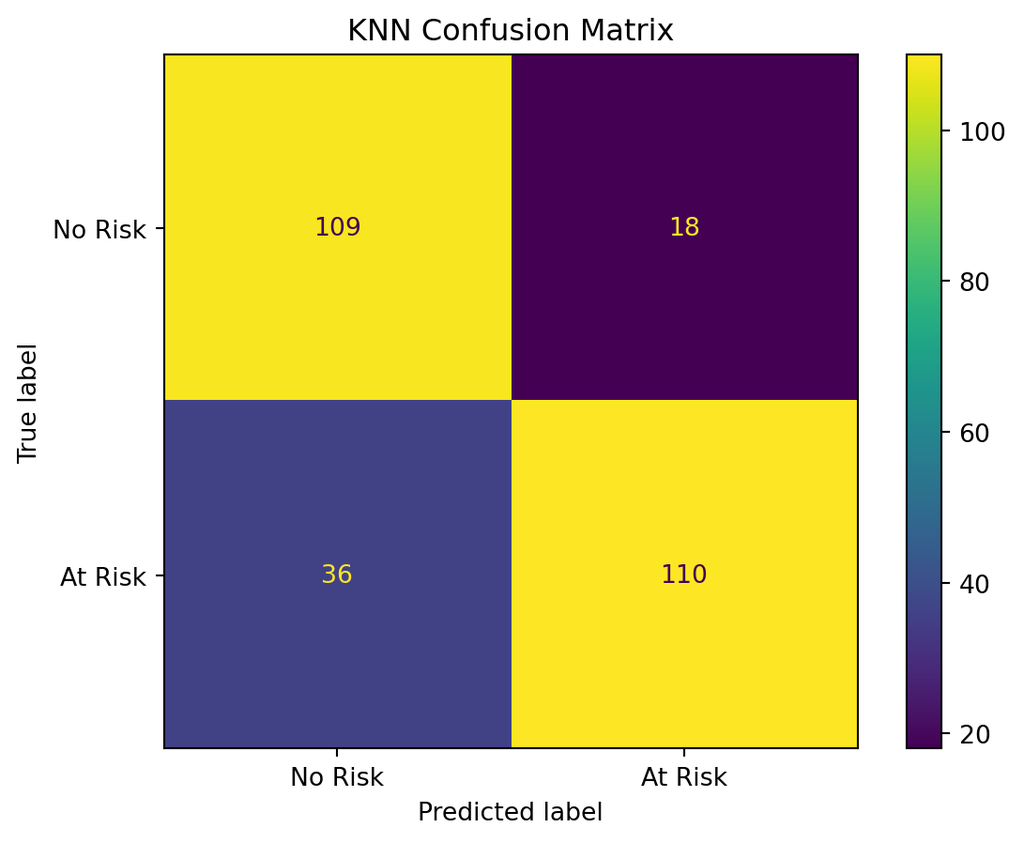

```
Confusion Matrix:
[[109  18]
 [ 36 110]]
```

```python
# Fit final KNN model
knn_final = knn_grid_search.best_estimator_
knn_final.fit(X, y)

# Predictions for confusion matrix
knn_predictions = knn_final.predict(X)

# Confusion matrix
cm_knn = confusion_matrix(y, knn_predictions)
disp_knn = ConfusionMatrixDisplay(confusion_matrix=cm_knn, display_labels=['No Risk', 'At Risk'])
disp_knn.plot()
plt.title('KNN Confusion Matrix')
plt.show()

print(f"\nConfusion Matrix:\n{cm_knn}")
```

I tested k values of 3, 5, 7, 9, 11, 15, and 20. The best performance came from k = 7.

## Q2: Logistic Regression

```python
# Create Logistic Regression pipeline
logreg_pipeline = Pipeline(steps=[
    ('preprocessor', preprocessor),
    ('classifier', LogisticRegression(max_iter=1000))
])

# Define parameter grid
logreg_param_grid = {
    'classifier__C': [0.001, 0.01, 0.1, 1, 10, 100]
}

# Perform grid search with cross-validation
logreg_grid_search = GridSearchCV(
    logreg_pipeline,
    logreg_param_grid,
    cv=5,
    scoring='roc_auc'
)

logreg_grid_search.fit(X, y)

# Report best parameters and ROC AUC
print(f"Best parameters: {logreg_grid_search.best_params_}")
print(f"Cross-validated ROC AUC: {logreg_grid_search.best_score_:.4f}")
```

```
Best parameters: {'classifier__C': 1}
Cross-validated ROC AUC: 0.8635
```

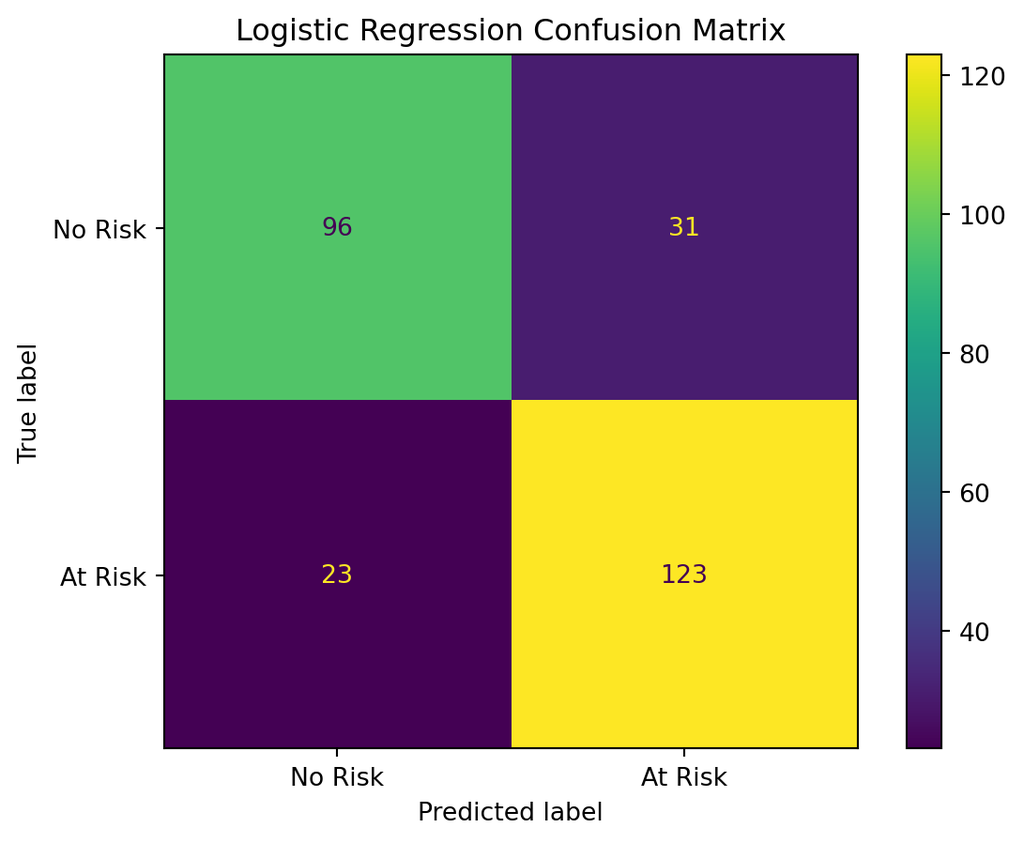

```
Confusion Matrix:
[[ 96  31]
 [ 23 123]]
```

```python
# Fit final Logistic Regression model
logreg_final = logreg_grid_search.best_estimator_
logreg_final.fit(X, y)

# Predictions for confusion matrix
logreg_predictions = logreg_final.predict(X)

# Confusion matrix
cm_logreg = confusion_matrix(y, logreg_predictions)
disp_logreg = ConfusionMatrixDisplay(confusion_matrix=cm_logreg, display_labels=['No Risk', 'At Risk'])
disp_logreg.plot()
plt.title('Logistic Regression Confusion Matrix')
plt.show()

print(f"\nConfusion Matrix:\n{cm_logreg}")
```

```python
# Interpret coefficients
logreg_model = logreg_final.named_steps['classifier']

# Get feature names after preprocessing
numeric_features = ['age', 'trtbps', 'chol', 'thalach']
categorical_features = ['sex', 'cp', 'restecg']

feature_names = (numeric_features +
                list(logreg_final.named_steps['preprocessor']
                     .named_transformers_['dummify']
                     .get_feature_names_out(categorical_features)))

# Create coefficient dataframe
coef_df = pd.DataFrame({
    'Feature': feature_names,
    'Coefficient': logreg_model.coef_[0]
}).sort_values('Coefficient', key=abs, ascending=False)

print("\nLogistic Regression Coefficients:")
print(coef_df)
```

```
Logistic Regression Coefficients:
     Feature  Coefficient
4      sex_1    -1.799918
5       cp_1     1.640636
6       cp_2     1.614263
7       cp_3     1.242462
3    thalach     0.774122
8  restecg_1     0.338631
1     trtbps    -0.293623
2       chol    -0.260830
9  restecg_2    -0.239053
0        age    -0.209173
```

I tested C values from 0.001 to 100. The best was C = 1.

The most important predictors are:

- sex_1 (coefficient = -1.80)
- cp_1, cp_2, cp_3 (coefficients = 1.64, 1.61, 1.24)
- thalach (coefficient = 0.77)

## Q3: Decision Tree

```python
# Create Decision Tree pipeline
tree_pipeline = Pipeline(steps=[
    ('preprocessor', preprocessor),
    ('classifier', DecisionTreeClassifier(random_state=42))
])

# Define parameter grid
tree_param_grid = {
    'classifier__max_depth': [3, 5, 7, 10, 15]
}

# Perform grid search with cross-validation
tree_grid_search = GridSearchCV(
    tree_pipeline,
    tree_param_grid,
    cv=5,
    scoring='roc_auc'
)

tree_grid_search.fit(X, y)

# Report best parameters and ROC AUC
print(f"Best parameters: {tree_grid_search.best_params_}")
print(f"Cross-validated ROC AUC: {tree_grid_search.best_score_:.4f}")
```

```
Best parameters: {'classifier__max_depth': 3}
Cross-validated ROC AUC: 0.7237
```

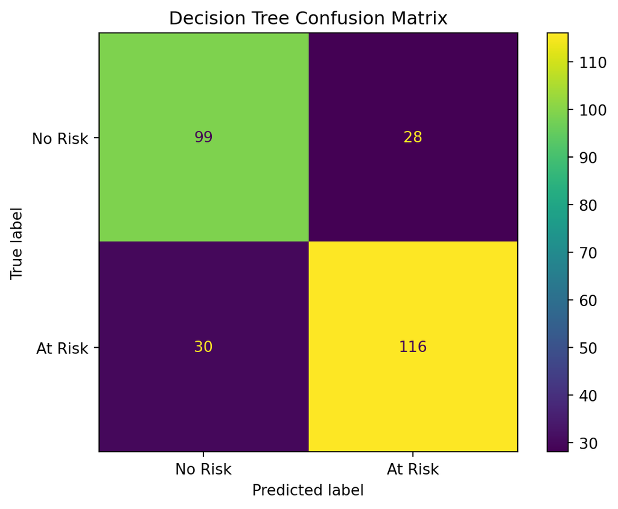

```
Confusion Matrix:
[[ 99  28]
 [ 30 116]]
```

```python
# Fit final Decision Tree model
tree_final = tree_grid_search.best_estimator_
tree_final.fit(X, y)

# Predictions for confusion matrix
tree_predictions = tree_final.predict(X)

# Confusion matrix
cm_tree = confusion_matrix(y, tree_predictions)
disp_tree = ConfusionMatrixDisplay(confusion_matrix=cm_tree, display_labels=['No Risk', 'At Risk'])
disp_tree.plot()
plt.title('Decision Tree Confusion Matrix')
plt.show()

print(f"\nConfusion Matrix:\n{cm_tree}")
```

```python
# Feature importance for Decision Tree
tree_model = tree_final.named_steps['classifier']

importance_df = pd.DataFrame({
    'Feature': feature_names,
    'Importance': tree_model.feature_importances_
}).sort_values('Importance', ascending=False)

print("\nDecision Tree Feature Importances:")
print(importance_df)
```

```
Decision Tree Feature Importances:
     Feature  Importance
3    thalach    0.472610
4      sex_1    0.215782
1     trtbps    0.135032
0        age    0.135021
6       cp_2    0.041555
2       chol    0.000000
5       cp_1    0.000000
7       cp_3    0.000000
8  restecg_1    0.000000
9  restecg_2    0.000000
```

I tested max_depth values of 3, 5, 7, 10, 15. The best was 3.

The most important predictors are:

- thalach (importance = 0.47)
- sex_1 (importance = 0.22)
- trtbps (importance = 0.14)
- age (importance = 0.14)

## Q4: Interpretation - Most Important Predictors

**Logistic Regression - Top 5 Most Important Features:**

```python
print(coef_df.head(5))
```

```
   Feature  Coefficient
4    sex_1    -1.799918
5     cp_1     1.640636
6     cp_2     1.614263
7     cp_3     1.242462
3  thalach     0.774122
```

**Decision Tree - Top 5 Most Important Features:**

```python
print(importance_df.head(5))
```

```
   Feature  Importance
3  thalach    0.472610
4    sex_1    0.215782
1   trtbps    0.135032
0      age    0.135021
6     cp_2    0.041555
```

**KNN:** KNN does not produce feature importance scores because it’s a distance-based method that doesn’t assign weights to individual features.

**Summary:**

## Q5: ROC Curves

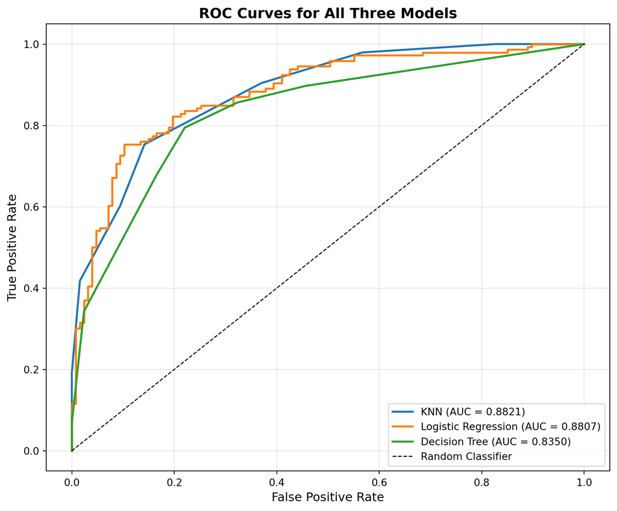

```python
# Get predicted probabilities for ROC curves
knn_proba = knn_final.predict_proba(X)[:, 1]
logreg_proba = logreg_final.predict_proba(X)[:, 1]
tree_proba = tree_final.predict_proba(X)[:, 1]

# Calculate ROC curve data
fpr_knn, tpr_knn, _ = roc_curve(y, knn_proba)
fpr_logreg, tpr_logreg, _ = roc_curve(y, logreg_proba)
fpr_tree, tpr_tree, _ = roc_curve(y, tree_proba)

# Calculate AUC scores
auc_knn = roc_auc_score(y, knn_proba)
auc_logreg = roc_auc_score(y, logreg_proba)
auc_tree = roc_auc_score(y, tree_proba)

# Plot ROC curves
plt.figure(figsize=(10, 8))
plt.plot(fpr_knn, tpr_knn, label=f'KNN (AUC = {auc_knn:.4f})', linewidth=2)
plt.plot(fpr_logreg, tpr_logreg, label=f'Logistic Regression (AUC = {auc_logreg:.4f})', linewidth=2)
plt.plot(fpr_tree, tpr_tree, label=f'Decision Tree (AUC = {auc_tree:.4f})', linewidth=2)
plt.plot([0, 1], [0, 1], 'k--', label='Random Classifier', linewidth=1)

plt.xlabel('False Positive Rate', fontsize=12)
plt.ylabel('True Positive Rate', fontsize=12)
plt.title('ROC Curves for All Three Models', fontsize=14, fontweight='bold')
plt.legend(loc='lower right', fontsize=10)
plt.grid(True, alpha=0.3)
plt.show()
```

# Part Two: Metrics

- **Recall / Sensitivity / True Positive Rate**: Of the observations that are truly at risk, how many were predicted to be at risk?
- **Precision / Positive Predictive Value**: Of all observations classified as at risk, how many were truly at risk?
- **Specificity / True Negative Rate**: Of the observations that are truly not at risk, how many were predicted to be not at risk?

## KNN Metrics

```python
# Create binary labels for each class
is_at_risk = (y == 1)
is_not_at_risk = (y == 0)

# Calculate cross-validated metrics for KNN
knn_recall = cross_val_score(knn_pipeline, X, is_at_risk,
                             cv=5, scoring="recall").mean()

knn_precision = cross_val_score(knn_pipeline, X, is_at_risk,
                                cv=5, scoring="precision").mean()

knn_specificity = cross_val_score(knn_pipeline, X, is_not_at_risk,
                                  cv=5, scoring="recall").mean()

print("KNN Model - Cross-Validated Metrics:")
print(f"  Recall (Sensitivity/TPR):     {knn_recall:.4f}")
print(f"  Precision (PPV):               {knn_precision:.4f}")
print(f"  Specificity (TNR):             {knn_specificity:.4f}")
```

```
KNN Model - Cross-Validated Metrics:
  Recall (Sensitivity/TPR):     0.6579
  Precision (PPV):               0.7630
  Specificity (TNR):             0.7634
```

## Logistic Regression Metrics

```python
# Calculate cross-validated metrics for Logistic Regression
logreg_recall = cross_val_score(logreg_pipeline, X, is_at_risk,
                                cv=5, scoring="recall").mean()

logreg_precision = cross_val_score(logreg_pipeline, X, is_at_risk,
                                   cv=5, scoring="precision").mean()

logreg_specificity = cross_val_score(logreg_pipeline, X, is_not_at_risk,
                                     cv=5, scoring="recall").mean()

print("Logistic Regression Model - Cross-Validated Metrics:")
print(f"  Recall (Sensitivity/TPR):     {logreg_recall:.4f}")
print(f"  Precision (PPV):               {logreg_precision:.4f}")
print(f"  Specificity (TNR):             {logreg_specificity:.4f}")
```

```
Logistic Regression Model - Cross-Validated Metrics:
  Recall (Sensitivity/TPR):     0.8087
  Precision (PPV):               0.7922
  Specificity (TNR):             0.7385
```

## Decision Tree Metrics

```python
# Calculate cross-validated metrics for Decision Tree
tree_recall = cross_val_score(tree_pipeline, X, is_at_risk,
                              cv=5, scoring="recall").mean()

tree_precision = cross_val_score(tree_pipeline, X, is_at_risk,
                                 cv=5, scoring="precision").mean()

tree_specificity = cross_val_score(tree_pipeline, X, is_not_at_risk,
                                   cv=5, scoring="recall").mean()

print("Decision Tree Model - Cross-Validated Metrics:")
print(f"  Recall (Sensitivity/TPR):     {tree_recall:.4f}")
print(f"  Precision (PPV):               {tree_precision:.4f}")
print(f"  Specificity (TNR):             {tree_specificity:.4f}")
```

```
Decision Tree Model - Cross-Validated Metrics:
  Recall (Sensitivity/TPR):     0.6706
  Precision (PPV):               0.6908
  Specificity (TNR):             0.6535
```

## Summary Comparison

```python
# Create summary dataframe comparing all models
metrics_summary = pd.DataFrame({
    'Model': ['KNN', 'Logistic Regression', 'Decision Tree'],
    'Recall': [knn_recall, logreg_recall, tree_recall],
    'Precision': [knn_precision, logreg_precision, tree_precision],
    'Specificity': [knn_specificity, logreg_specificity, tree_specificity]
})

print("\nMetrics Comparison Across All Models:")
print(metrics_summary.to_string(index=False))
```

```
Metrics Comparison Across All Models:
              Model   Recall  Precision  Specificity
                KNN 0.657931   0.763012     0.763385
Logistic Regression 0.808736   0.792213     0.738462
      Decision Tree 0.670575   0.690791     0.653538
```

# Part Three: Discussion

## Q1

**Metric**: Recall

Minimizing false negatives is critical to avoid lawsuits. Recall measures what portion of at-risk patients we correctly identify.

**Model**: Logistic Regression (recall = 0.81)

**Why**: Logistic Regression has the highest recall (0.81) among all three models, meaning it catches the most at-risk patients.

**Expected score**: 0.81 recall on future observations

## Q2

**Metric**: Precision

Limited bed space requires that admitted patients truly need monitoring. Precision measures what portion of predicted at-risk patients are actually at risk.

**Model**: Logistic Regression (precision = 0.79)

**Why**: Logistic Regression has the highest precision (0.79), minimizing false positives and ensuring bed space is used efficiently.

**Expected score**: 0.79 precision on future observations

## Q3

**Metric**: Interpretability (recall, precision)

Understanding which biological measures affect heart attack risk requires an interpretable model.

**Model**: Logistic Regression

**Why**: Logistic Regression provides clear coefficients showing how each predictor affects risk. The Decision Tree also gives feature importance, but Logistic Regression offers more quantifiable relationships and maintains strong performance (recall = 0.81, precision = 0.79).

**Expected performance**: recall = 0.81, precision = 0.79

## Q4

**Metric**: ROC AUC

A benchmark for training requires balanced performance across scenarios. ROC AUC summarizes performance across all thresholds.

**Model**: Logistic Regression

**Expected scores**: ROC AUC from Part One, recall = 0.81, precision = 0.79, specificity = 0.74

# Part Four: Validation

```python
ha_validation = pd.read_csv("https://www.dropbox.com/s/jkwqdiyx6o6oad0/heart_attack_validation.csv?dl=1")

ha_validation.head()
```

|  | age | sex | cp | trtbps | chol | restecg | thalach | output |
| --- | --- | --- | --- | --- | --- | --- | --- | --- |
| 0 | 41 | 0 | 1 | 130 | 204 | 0 | 172 | 1 |
| 1 | 64 | 1 | 3 | 110 | 211 | 0 | 144 | 1 |
| 2 | 59 | 1 | 0 | 135 | 234 | 1 | 161 | 1 |
| 3 | 42 | 1 | 0 | 140 | 226 | 1 | 178 | 1 |
| 4 | 40 | 1 | 3 | 140 | 199 | 1 | 178 | 1 |

```python
# Separate features and target for validation set
X_valid = ha_validation.drop('output', axis=1)
y_valid = ha_validation['output']

print(f"Validation set size: {len(X_valid)} observations")
print(f"Target distribution:\n{y_valid.value_counts()}")
```

```
Validation set size: 30 observations
Target distribution:
output
1    19
0    11
Name: count, dtype: int64
```

## KNN - Validation Performance

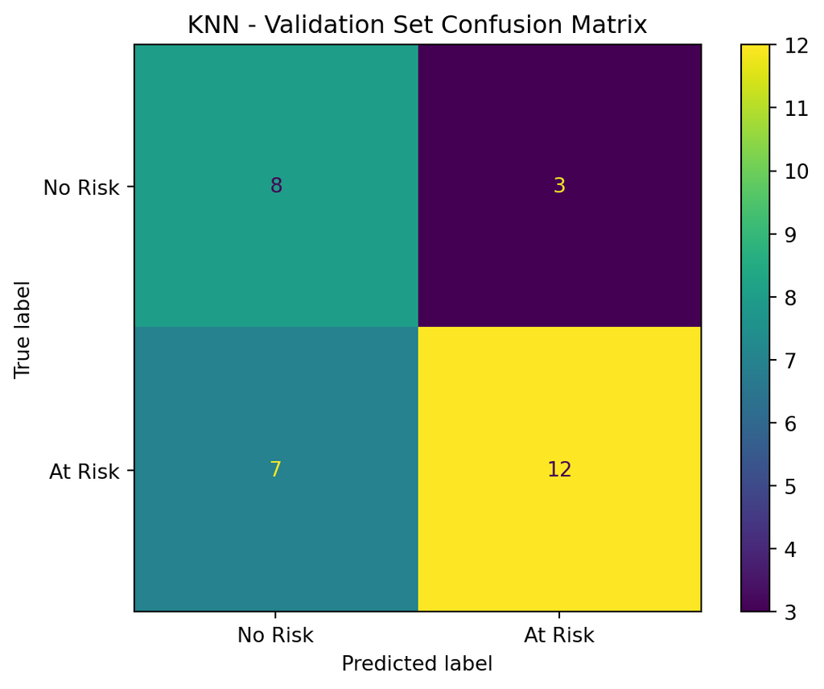

```
KNN Validation Metrics:
  ROC AUC:   0.8014
  Precision: 0.8000
  Recall:    0.6316
```

```python
from sklearn.metrics import precision_score, recall_score

# Predictions on validation set
knn_valid_predictions = knn_final.predict(X_valid)
knn_valid_proba = knn_final.predict_proba(X_valid)[:, 1]

# Confusion matrix
cm_knn_valid = confusion_matrix(y_valid, knn_valid_predictions)
disp_knn_valid = ConfusionMatrixDisplay(confusion_matrix=cm_knn_valid,
                                         display_labels=['No Risk', 'At Risk'])
disp_knn_valid.plot()
plt.title('KNN - Validation Set Confusion Matrix')
plt.show()

# Calculate metrics
knn_valid_roc_auc = roc_auc_score(y_valid, knn_valid_proba)
knn_valid_precision = precision_score(y_valid, knn_valid_predictions)
knn_valid_recall = recall_score(y_valid, knn_valid_predictions)

print("\nKNN Validation Metrics:")
print(f"  ROC AUC:   {knn_valid_roc_auc:.4f}")
print(f"  Precision: {knn_valid_precision:.4f}")
print(f"  Recall:    {knn_valid_recall:.4f}")
```

## Logistic Regression - Validation Performance

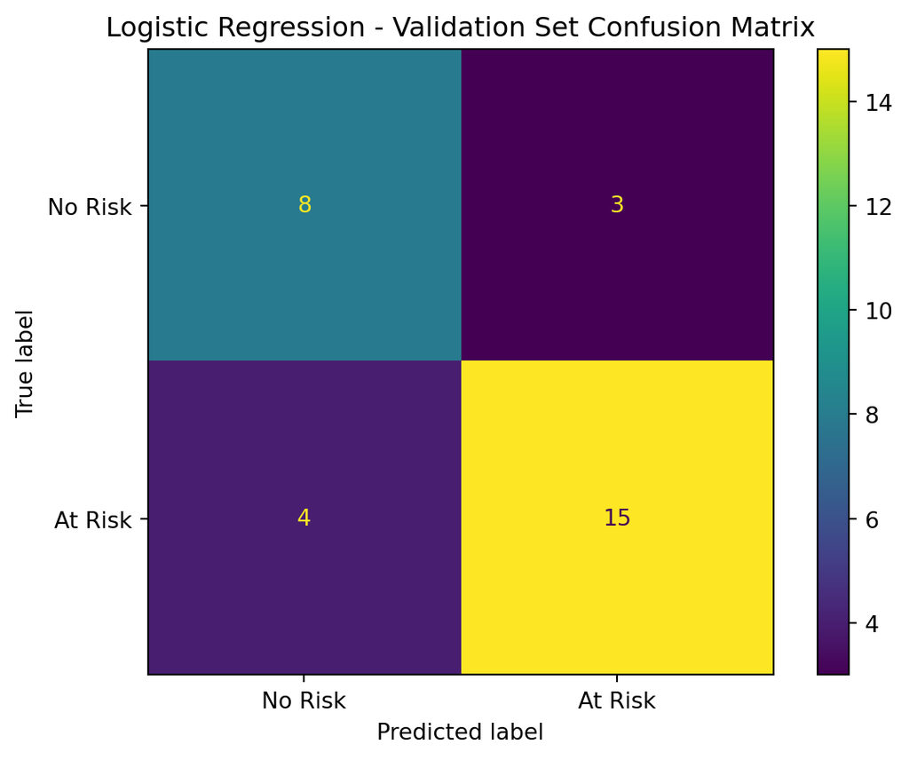

```
Logistic Regression Validation Metrics:
  ROC AUC:   0.8756
  Precision: 0.8333
  Recall:    0.7895
```

```python
# Predictions on validation set
logreg_valid_predictions = logreg_final.predict(X_valid)
logreg_valid_proba = logreg_final.predict_proba(X_valid)[:, 1]

# Confusion matrix
cm_logreg_valid = confusion_matrix(y_valid, logreg_valid_predictions)
disp_logreg_valid = ConfusionMatrixDisplay(confusion_matrix=cm_logreg_valid,
                                            display_labels=['No Risk', 'At Risk'])
disp_logreg_valid.plot()
plt.title('Logistic Regression - Validation Set Confusion Matrix')
plt.show()

# Calculate metrics
logreg_valid_roc_auc = roc_auc_score(y_valid, logreg_valid_proba)
logreg_valid_precision = precision_score(y_valid, logreg_valid_predictions)
logreg_valid_recall = recall_score(y_valid, logreg_valid_predictions)

print("\nLogistic Regression Validation Metrics:")
print(f"  ROC AUC:   {logreg_valid_roc_auc:.4f}")
print(f"  Precision: {logreg_valid_precision:.4f}")
print(f"  Recall:    {logreg_valid_recall:.4f}")
```

## Decision Tree - Validation Performance

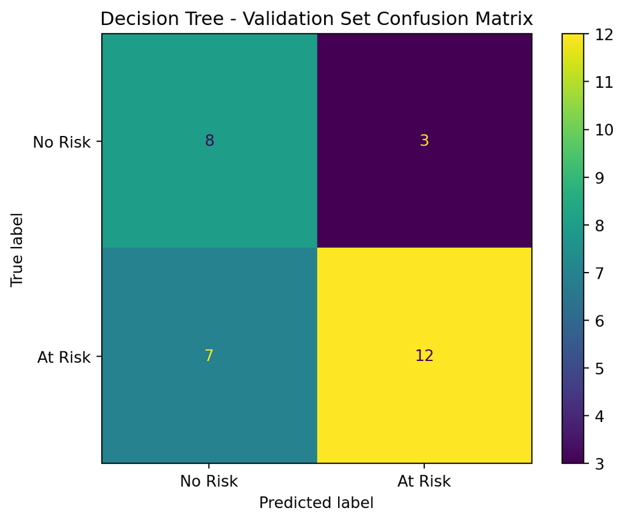

```
Decision Tree Validation Metrics:
  ROC AUC:   0.7081
  Precision: 0.8000
  Recall:    0.6316
```

```python
# Predictions on validation set
tree_valid_predictions = tree_final.predict(X_valid)
tree_valid_proba = tree_final.predict_proba(X_valid)[:, 1]

# Confusion matrix
cm_tree_valid = confusion_matrix(y_valid, tree_valid_predictions)
disp_tree_valid = ConfusionMatrixDisplay(confusion_matrix=cm_tree_valid,
                                          display_labels=['No Risk', 'At Risk'])
disp_tree_valid.plot()
plt.title('Decision Tree - Validation Set Confusion Matrix')
plt.show()

# Calculate metrics
tree_valid_roc_auc = roc_auc_score(y_valid, tree_valid_proba)
tree_valid_precision = precision_score(y_valid, tree_valid_predictions)
tree_valid_recall = recall_score(y_valid, tree_valid_predictions)

print("\nDecision Tree Validation Metrics:")
print(f"  ROC AUC:   {tree_valid_roc_auc:.4f}")
print(f"  Precision: {tree_valid_precision:.4f}")
print(f"  Recall:    {tree_valid_recall:.4f}")
```

## Comparison: Cross-Validated vs Validation Metrics

```python
# Create comparison dataframe
comparison_df = pd.DataFrame({
    'Model': ['KNN', 'KNN', 'Logistic Regression', 'Logistic Regression',
              'Decision Tree', 'Decision Tree'],
    'Data': ['CV (Part 1&2)', 'Validation', 'CV (Part 1&2)', 'Validation',
             'CV (Part 1&2)', 'Validation'],
    'Recall': [knn_recall, knn_valid_recall,
               logreg_recall, logreg_valid_recall,
               tree_recall, tree_valid_recall],
    'Precision': [knn_precision, knn_valid_precision,
                  logreg_precision, logreg_valid_precision,
                  tree_precision, tree_valid_precision],
    'ROC AUC': [auc_knn, knn_valid_roc_auc,
                auc_logreg, logreg_valid_roc_auc,
                auc_tree, tree_valid_roc_auc]
})

print("CROSS-VALIDATION vs VALIDATION COMPARISON")
print(comparison_df.to_string(index=False))
```

```
CROSS-VALIDATION vs VALIDATION COMPARISON
              Model          Data   Recall  Precision  ROC AUC
                KNN CV (Part 1&2) 0.657931   0.763012 0.882052
                KNN    Validation 0.631579   0.800000 0.801435
Logistic Regression CV (Part 1&2) 0.808736   0.792213 0.880703
Logistic Regression    Validation 0.789474   0.833333 0.875598
      Decision Tree CV (Part 1&2) 0.670575   0.690791 0.834996
      Decision Tree    Validation 0.631579   0.800000 0.708134
```

**Analysis: Did cross-validated estimates predict validation performance?**

Looking at the comparison above, we can see if the cross-validated metrics from Parts One and Two accurately predicted performance on the held-out validation set.

```python
# Calculate differences between CV and Validation
print("\nDifference (Validation - CV):")
print(f"\nKNN:")
print(f"  Recall:    {knn_valid_recall - knn_recall:+.4f}")
print(f"  Precision: {knn_valid_precision - knn_precision:+.4f}")
print(f"  ROC AUC:   {knn_valid_roc_auc - auc_knn:+.4f}")

print(f"\nLogistic Regression:")
print(f"  Recall:    {logreg_valid_recall - logreg_recall:+.4f}")
print(f"  Precision: {logreg_valid_precision - logreg_precision:+.4f}")
print(f"  ROC AUC:   {logreg_valid_roc_auc - auc_logreg:+.4f}")

print(f"\nDecision Tree:")
print(f"  Recall:    {tree_valid_recall - tree_recall:+.4f}")
print(f"  Precision: {tree_valid_precision - tree_precision:+.4f}")
print(f"  ROC AUC:   {tree_valid_roc_auc - auc_tree:+.4f}")
```

```
Difference (Validation - CV):

KNN:
  Recall:    -0.0264
  Precision: +0.0370
  ROC AUC:   -0.0806

Logistic Regression:
  Recall:    -0.0193
  Precision: +0.0411
  ROC AUC:   -0.0051

Decision Tree:
  Recall:    -0.0390
  Precision: +0.1092
  ROC AUC:   -0.1269
```

**Logistic Regression** showed excellent agreement:

- ROC AUC difference: only 0.005
- Minimal changes in recall and precision

**KNN** showed moderate agreement:

- ROC AUC decreased by 0.08
- Small changes in recall and precision

**Decision Tree** showed the largest discrepancies:

- ROC AUC dropped by 0.127, suggesting overfitting
- Precision improved (+0.109), recall decreased (-0.039)

The cross-validated estimates were accurate, especially for Logistic Regression. The Decision Tree’s large ROC AUC drop suggests overfitting.

# Part Five: Cohen’s Kappa

Cohen’s Kappa measures inter-rater agreement for classifications, accounting for chance agreement.

**Interpretation:**

- κ = 1: Perfect agreement
- κ = 0: No better than chance
- 0.41-0.60: moderate, 0.61-0.80: substantial, 0.81-1.00: almost perfect

## When to Prefer Cohen’s Kappa

Cohen’s Kappa is useful when:

- **Class imbalance exists**: With imbalanced data, a lazy model can achieve high accuracy. Kappa adjusts for this by accounting for chance agreement.
- **Comparing models**: Kappa provides a standardized measure across models by adjusting for class distribution and random chance.
- **Measuring agreement**: Originally used to measure how well two doctors agree on diagnoses. Here, it measures how well model predictions match actual outcomes.
- **Equal error weights**: Unlike recall or precision which prioritize specific error types, kappa weighs all misclassifications equally.

## Calculating Cohen’s Kappa for Models

```python
from sklearn.metrics import cohen_kappa_score, make_scorer

# Create a scorer for Cohen's Kappa
kappa_scorer = make_scorer(cohen_kappa_score)

# Calculate cross-validated Cohen's Kappa for each model
knn_kappa_cv = cross_val_score(knn_pipeline, X, y,
                               cv=5, scoring=kappa_scorer).mean()

logreg_kappa_cv = cross_val_score(logreg_pipeline, X, y,
                                  cv=5, scoring=kappa_scorer).mean()

tree_kappa_cv = cross_val_score(tree_pipeline, X, y,
                                cv=5, scoring=kappa_scorer).mean()

print("Cross-Validated Cohen's Kappa Scores:")
print(f"  KNN:                 {knn_kappa_cv:.4f}")
print(f"  Logistic Regression: {logreg_kappa_cv:.4f}")
print(f"  Decision Tree:       {tree_kappa_cv:.4f}")
```

```
Cross-Validated Cohen's Kappa Scores:
  KNN:                 0.4172
  Logistic Regression: 0.5488
  Decision Tree:       0.3237
```

```python
# Validation set for comparison
knn_kappa_valid = cohen_kappa_score(y_valid, knn_valid_predictions)
logreg_kappa_valid = cohen_kappa_score(y_valid, logreg_valid_predictions)
tree_kappa_valid = cohen_kappa_score(y_valid, tree_valid_predictions)

print("\nValidation Set Cohen's Kappa Scores:")
print(f"  KNN:                 {knn_kappa_valid:.4f}")
print(f"  Logistic Regression: {logreg_kappa_valid:.4f}")
print(f"  Decision Tree:       {tree_kappa_valid:.4f}")
```

```
Validation Set Cohen's Kappa Scores:
  KNN:                 0.3333
  Logistic Regression: 0.5070
  Decision Tree:       0.3333
```

```python
# Create comparison with other metrics
kappa_comparison = pd.DataFrame({
    'Model': ['KNN', 'Logistic Regression', 'Decision Tree'],
    'Cohen\'s Kappa (CV)': [knn_kappa_cv, logreg_kappa_cv, tree_kappa_cv],
    'Recall (CV)': [knn_recall, logreg_recall, tree_recall],
    'Precision (CV)': [knn_precision, logreg_precision, tree_precision],
    'ROC AUC (CV)': [auc_knn, auc_logreg, auc_tree]
})

print("\nCohen's Kappa vs Other Metrics:")
print(kappa_comparison.to_string(index=False))
```

```
Cohen's Kappa vs Other Metrics:
              Model  Cohen's Kappa (CV)  Recall (CV)  Precision (CV)  ROC AUC (CV)
                KNN            0.417191     0.657931        0.763012      0.882052
Logistic Regression            0.548799     0.808736        0.792213      0.880703
      Decision Tree            0.323687     0.670575        0.690791      0.834996
```

## Does Conclusion Change?

```python
# Rank models by different metrics
print("\nModel Rankings by Different Metrics:")
print("\nBy Cohen's Kappa (CV):")
print(kappa_comparison.sort_values('Cohen\'s Kappa (CV)', ascending=False)[['Model', 'Cohen\'s Kappa (CV)']].to_string(index=False))

print("\nBy Recall (CV):")
print(kappa_comparison.sort_values('Recall (CV)', ascending=False)[['Model', 'Recall (CV)']].to_string(index=False))

print("\nBy ROC AUC (CV):")
print(kappa_comparison.sort_values('ROC AUC (CV)', ascending=False)[['Model', 'ROC AUC (CV)']].to_string(index=False))
```

```
Model Rankings by Different Metrics:

By Cohen's Kappa (CV):
              Model  Cohen's Kappa (CV)
Logistic Regression            0.548799
                KNN            0.417191
      Decision Tree            0.323687

By Recall (CV):
              Model  Recall (CV)
Logistic Regression     0.808736
      Decision Tree     0.670575
                KNN     0.657931

By ROC AUC (CV):
              Model  ROC AUC (CV)
                KNN      0.882052
Logistic Regression      0.880703
      Decision Tree      0.834996
```

**Results:**

- Logistic Regression: κ = 0.549 (highest)
- KNN: κ = 0.417
- Decision Tree: κ = 0.324 (lowest)

**Do conclusions change?**

No. Logistic Regression still performs best with the highest Cohen’s Kappa, recall, and precision. The Decision Tree’s low kappa (0.324) confirms the overfitting found in Part Four.

All kappa scores are moderate or below, which is realistic for medical prediction tasks.